# ANOVA_Immunohistochemistry

KS

2026-01-14

# Introduction

The data presented below are part of a series of experiments completed during my MSc in Neuroscience ([Svendsen, 2023](https://hdl.handle.net/1880/116587)) and were later published in the Journal of Pharmacology and Experimental Therapeutics ([Svendsen et al., 2025](https://pubmed.ncbi.nlm.nih.gov/39921943/)). The data consist of confocal microscopy images of immunohistochemical staining for the neuronal activity marker cFos in L6-S1 spinal cord slices (Fig 1). The neurons within the spinal cord are discretely organized and the different layers receive signals from specific parts of the body. In this context, a larger number of cFos positive neurons located in the dorsal horn indicates greater nociceptive (pain) signalling from the stimulated tissue ([Harris, 1998](https://pubmed.ncbi.nlm.nih.gov/9434195/); [Abdullah et al., 2020](https://pubmed.ncbi.nlm.nih.gov/33026824/)). This is experiment used the dextran-sulfate sodium (DSS) model of inflammatory bowel disease [(Chassaing et al., 2015)](https://pubmed.ncbi.nlm.nih.gov/24510619/) and examined the efficacy of cannabigerol (CBG) as treatment for the associated acute visceral pain. Mice were divided in four groups:

1. Negative control mice received normal water and the drug vehicle (Water)
2. Positive control mice received DSS adn the drug vehicle (DSS)
3. Experimental group 1 which received DSS and 5mg/kg CBG DSS (CBG5)
4. Experimental group 2 which received DSS and 10mg/kg CBG (CBG10)

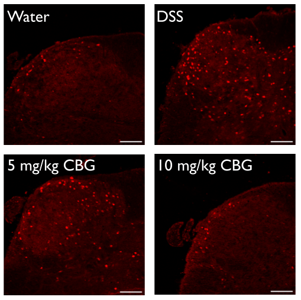

Fig 1. Example images of immunohistochemical staining for the neuronal activity marker cFos in the lumbosacral dorsal horn

#### Library

```r
library(tidyverse)
library(skimr)
library(car)
library(ggpubr)
library(RColorBrewer)
library(ggsignif)
library(rstatix)
```

# Cleaning

#### Import and inspect data.

```r
cfos.dat <- read.csv(file = "./CBG_cFos.csv", header = T, sep =",")

head(cfos.dat)
```

```
##   Count Condition  Mouse
## 1    17     CBG10 R1D2.3
## 2     6     CBG10 R1D2.3
## 3     6     CBG10 R1D2.3
## 4     7     CBG10 R1D2.3
## 5     9     CBG10 R1D2.3
## 6     5     CBG10 R1D2.3
```

#### Rename headers and rename negative control.

```r
cfos.dat <- cfos.dat %>% #lowercase headers
  rename_with(tolower)
head(cfos.dat)
```

```
##   count condition  mouse
## 1    17     CBG10 R1D2.3
## 2     6     CBG10 R1D2.3
## 3     6     CBG10 R1D2.3
## 4     7     CBG10 R1D2.3
## 5     9     CBG10 R1D2.3
## 6     5     CBG10 R1D2.3
```

```r
cfos.dat[cfos.dat == "Veh"]<- "Water" #replace "Veh" with "Water"
```

#### Verify data types.

```r
is.factor(cfos.dat$condiion)
```

```
## [1] FALSE
```

```r
cfos.dat$condition = as.factor(cfos.dat$condition)
is.factor(cfos.dat$condition)
```

```
## [1] TRUE
```

```r
is.factor(cfos.dat$mouse)
```

```
## [1] FALSE
```

```r
cfos.dat$mouse = as.factor(cfos.dat$mouse)
is.factor(cfos.dat$mouse)
```

```
## [1] TRUE
```

#### Reorder data

```r
sort_order <- c("Water", "DSS", "CBG5", "CBG10") #define order

cfos.dat_sorted <- cfos.dat %>%
  mutate(condition = fct_relevel(condition, sort_order)) %>%
  arrange(condition)
```

# Analysis

#### Compute average cFos count per mouse and store n value.

The raw data consist of multiple images of different slices of spinal column within the relavent level; subsequently, the average of for each mouse must be computed. We will also store the resulting n-values in an object for easy reporting.

```r
mouse.dat <- aggregate(cfos.dat_sorted[,1], list(cfos.dat_sorted$mouse, cfos.dat_sorted$condition), FUN = mean)

names(mouse.dat)[1]<-'mouse'
names(mouse.dat)[2]<-'condition'
names(mouse.dat)[3]<-'count_avg'

n_values <-table(mouse.dat$condition)
print(n_values)
```

```
##
## Water   DSS  CBG5 CBG10
##     8     7     7     6
```

#### ANOVA and pairwise comparison using Tukey’s honestly significant difference

```r
anova.cfos <- aov(count_avg ~ condition, data = mouse.dat)
anova <- Anova(anova.cfos, type ="II")
print(anova)
```

```
## Anova Table (Type II tests)
##
## Response: count_avg
##           Sum Sq Df F value   Pr(>F)
## condition 1260.8  3  7.2751 0.001233 **
## Residuals 1386.5 24
## ---
## Signif. codes:  0 '***' 0.001 '**' 0.01 '*' 0.05 '.' 0.1 ' ' 1
```

```r
tukey <- tukey_hsd(anova.cfos)
print(knitr::kable(tukey, caption = "TukeyHSD"))
```

```
##
##
## Table: TukeyHSD
##
## |term      |group1 |group2 | null.value|    estimate|    conf.low| conf.high|   p.adj|p.adj.signif |
## |:---------|:------|:------|----------:|-----------:|-----------:|---------:|-------:|:------------|
## |condition |Water  |DSS    |          0|  10.9136125|   0.0621159| 21.765109| 0.04830|*            |
## |condition |Water  |CBG5   |          0|  10.6268322|  -0.2246644| 21.478329| 0.05640|ns           |
## |condition |Water  |CBG10  |          0|  -5.0677083| -16.3912276|  6.255811| 0.61200|ns           |
## |condition |DSS    |CBG5   |          0|  -0.2867803| -11.4941578| 10.920597| 1.00000|ns           |
## |condition |DSS    |CBG10  |          0| -15.9813209| -27.6463292| -4.316313| 0.00475|**           |
## |condition |CBG5   |CBG10  |          0| -15.6945406| -27.3595490| -4.029532| 0.00560|**           |
```

The ANOVA showed a main effect of condition. The follow-up pairwise comparisons showed the negative and positive control groups (Water and DSS, respectively) to be significantly different suggesting that the experimental model performed as expected; therefore, we can examine our experimental groups. There was no effect of 5mg/kg CBG (CBG5); however, 10mg/kg CBG (CBG10) showed a significant reduction compared to the DSS group.

# Visulation

#### Select pairwise comparisons for figure

Based on the results discussed above, there are four main comparisons that should be shown in the figure:

1. Water and DSS to demonstrate that the model performed as expected.
2. CBG5 and DSS to show that this dose was ineffective.
3. CBG10 and DSS to show that this dose was effective.
4. CBG10 and water to show that this dose did not reduce responses below negative control values.

```r
tukey_figure <- tukey[c(1,3,4,5),] #select rows containing pairwise comparisons
```

#### Create Boxplot

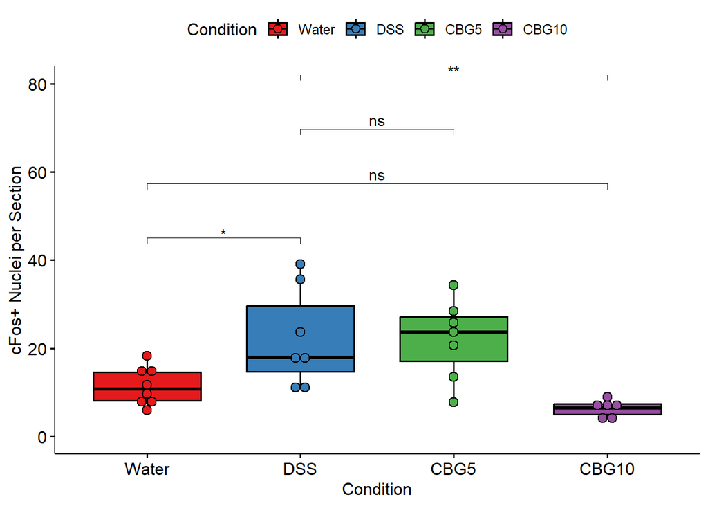

```r
bp <- ggboxplot(mouse.dat, x = "condition", y = "count_avg",
                fill = "condition",
                add = "dotplot" , add.params = list(size = 1.6, alpha = 1),
                ylab = "cFos+ Nuclei per Section", xlab = "Condition")+
  coord_cartesian(
    xlim = NULL,
    ylim = c(0, 80),
    expand = TRUE,
    default = FALSE,
    clip = "off")+
  stat_pvalue_manual(tukey_figure,
                     label = "p.adj.signif", #to show exact p-value use "p.adj"
                     y.position = 45, step.increase = 0.3) #p-value bars location

bp <- ggpar(bp, legend.title = "Condition") #rename legend

bp +scale_fill_brewer(palette ="Set1")
```

#### Print key statistics for write-up

```r
key_stats <- list("n_values" = n_values,"anova" = anova, "tukey_hsd" = knitr::kable(tukey))
print(key_stats)
```

```
## $n_values
##
## Water   DSS  CBG5 CBG10
##     8     7     7     6
##
## $anova
## Anova Table (Type II tests)
##
## Response: count_avg
##           Sum Sq Df F value   Pr(>F)
## condition 1260.8  3  7.2751 0.001233 **
## Residuals 1386.5 24
## ---
## Signif. codes:  0 '***' 0.001 '**' 0.01 '*' 0.05 '.' 0.1 ' ' 1
##
## $tukey_hsd
##
##
## |term      |group1 |group2 | null.value|    estimate|    conf.low| conf.high|   p.adj|p.adj.signif |
## |:---------|:------|:------|----------:|-----------:|-----------:|---------:|-------:|:------------|
## |condition |Water  |DSS    |          0|  10.9136125|   0.0621159| 21.765109| 0.04830|*            |
## |condition |Water  |CBG5   |          0|  10.6268322|  -0.2246644| 21.478329| 0.05640|ns           |
## |condition |Water  |CBG10  |          0|  -5.0677083| -16.3912276|  6.255811| 0.61200|ns           |
## |condition |DSS    |CBG5   |          0|  -0.2867803| -11.4941578| 10.920597| 1.00000|ns           |
## |condition |DSS    |CBG10  |          0| -15.9813209| -27.6463292| -4.316313| 0.00475|**           |
## |condition |CBG5   |CBG10  |          0| -15.6945406| -27.3595490| -4.029532| 0.00560|**           |
```

# Conclusion

Results showed a significant effect of condition (F(3) = 7.2751, p = 0.0012). Post-hoc analysis (Tukey HSD) showed significant differences between Water and DSS conditions(p = 0.0483), 10 mg/kg CBG and DSS (p = 0.0048), as well as 10 mg/kg CBG and 5mg/kg CBG (p = 0.0056). This data suggests that treatment with CBG at 10mg/kg ameliorated visceral nociception in DSS model of IBD.